# Chapter 2 Exercises

30 June, 2018

## Getting started with ggplot2

| manufacturer | model | displ | year | cyl | trans | drv | cty | hwy | fl | class |
| --- | --- | --- | --- | --- | --- | --- | --- | --- | --- | --- |
| audi | a4 | 1.8 | 1999 | 4 | auto(l5) | f | 18 | 29 | p | compact |
| audi | a4 | 1.8 | 1999 | 4 | manual(m5) | f | 21 | 29 | p | compact |
| audi | a4 | 2.0 | 2008 | 4 | manual(m6) | f | 20 | 31 | p | compact |
| audi | a4 | 2.0 | 2008 | 4 | auto(av) | f | 21 | 30 | p | compact |
| audi | a4 | 2.8 | 1999 | 6 | auto(l5) | f | 16 | 26 | p | compact |
| audi | a4 | 2.8 | 1999 | 6 | manual(m5) | f | 18 | 26 | p | compact |
| audi | a4 | 3.1 | 2008 | 6 | auto(av) | f | 18 | 27 | p | compact |
| audi | a4 quattro | 1.8 | 1999 | 4 | manual(m5) | 4 | 18 | 26 | p | compact |
| audi | a4 quattro | 1.8 | 1999 | 4 | auto(l5) | 4 | 16 | 25 | p | compact |
| audi | a4 quattro | 2.0 | 2008 | 4 | manual(m6) | 4 | 20 | 28 | p | compact |

[output cut: 224 more lines]

### Exercises 2.2.1

> **Question 1**:

> List five functions that you could use to get more information about the `mpg` data set.

> **Answer**: Some useful functions are:
> - `summary`: print some summary statistics for each variable
> - `View`: to see the whole data set in a nice spread-sheet like fashion
> - `str` : get info on the structure of the `mpg` object
> - `dplyr::glimps`: similar to `str` but much tidier
> - `class`: to get its class

```r
glimpse(mpg)
```

```
## Observations: 234
## Variables: 11
## $ manufacturer <chr> "audi", "audi", "audi", "audi", "audi", "audi", "...
## $ model        <chr> "a4", "a4", "a4", "a4", "a4", "a4", "a4", "a4 qua...
## $ displ        <dbl> 1.8, 1.8, 2.0, 2.0, 2.8, 2.8, 3.1, 1.8, 1.8, 2.0,...
## $ year         <int> 1999, 1999, 2008, 2008, 1999, 1999, 2008, 1999, 1...
## $ cyl          <int> 4, 4, 4, 4, 6, 6, 6, 4, 4, 4, 4, 6, 6, 6, 6, 6, 6...
## $ trans        <chr> "auto(l5)", "manual(m5)", "manual(m6)", "auto(av)...
## $ drv          <chr> "f", "f", "f", "f", "f", "f", "f", "4", "4", "4",...
## $ cty          <int> 18, 21, 20, 21, 16, 18, 18, 18, 16, 20, 19, 15, 1...
## $ hwy          <int> 29, 29, 31, 30, 26, 26, 27, 26, 25, 28, 27, 25, 2...
## $ fl           <chr> "p", "p", "p", "p", "p", "p", "p", "p", "p", "p",...
## $ class        <chr> "compact", "compact", "compact", "compact", "comp...
```

> **Question 2**:

> How can you find out what other datasets are included with ggplot2?

> **Answer**:

```r
pkg.data <- data(package = "ggplot2")
pkgs <- as.data.table(pkg.data$results)[, 3:4]

pkgs
```

| Item | Title |
| --- | --- |
| diamonds | Prices of 50,000 round cut diamonds |
| economics | US economic time series |
| economics_long | US economic time series |
| faithfuld | 2d density estimate of Old Faithful data |
| luv_colours | 'colors()' in Luv space |
| midwest | Midwest demographics |
| mpg | Fuel economy data from 1999 and 2008 for 38 popular models of car |
| msleep | An updated and expanded version of the mammals sleep dataset |
| presidential | Terms of 11 presidents from Eisenhower to Obama |
| seals | Vector field of seal movements |

[output cut: 1 more lines]

> **Question 3**:

> Apart from the US, most countries use fuel consumption, (`fuel consumed over fixed distance`) rather than fuel economy, (`distance travelled with fixed amount of fuel`).

> How could you convert cty and hwy into the European standard of 1/100km?

> **Answer**:

```r
mpgTol100km <- function(milespergallon) {
    GalloLiter <- 3.785411784
    MileKilometer <- 1.609344

    l100km <- (100 * GalloLiter) / (milespergallon * MileKilometer)
    l100km
}
```

> **Question 4**:

> Which manufacturer has the most models in this dataset?

```r
q4_1 <- mpg %>%
    group_by(manufacturer) %>%
    tally( sort = TRUE)
```

> Which model has the most variations?

```r
q4_2 <- mpg %>%
    group_by(manufacturer) %>%
    transmute("n" = length(unique(model))) %>%
    unique() %>%
    ungroup() %>%
    arrange(desc(n))
```

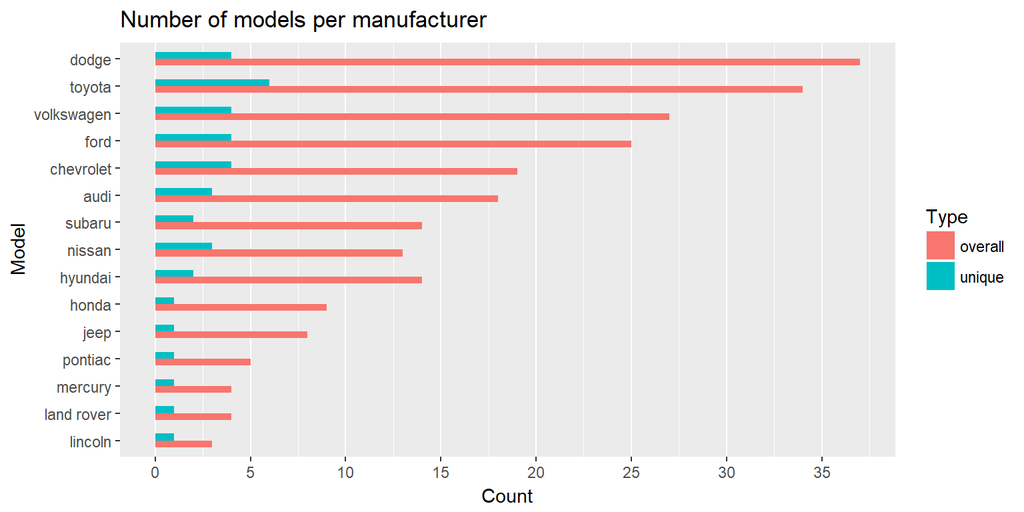

```r
df <- data.frame(rbind(q4_1, q4_2), "Type" = as.factor(rep(c("overall", "unique"), each = 15)))

ggplot(df, aes(x = reorder(as.factor(manufacturer), n), y = n, fill = Type)) +
    geom_bar(width = 0.5, stat = "identity", position = "dodge") +
    theme(panel.grid.major.y = element_blank(),
        panel.grid.minor.y = element_blank()) +
        scale_y_continuous(breaks = seq(0, 40, by = 5)) +
        ggtitle("Number of models per manufacturer") +
        labs(y = "Count", x = "Model") +
        coord_flip()
```

> Does your answer change if you remove the redundant specifications of drive train (e.g., “pathfinder 4wd”, ’a4 quattro") from the model name?

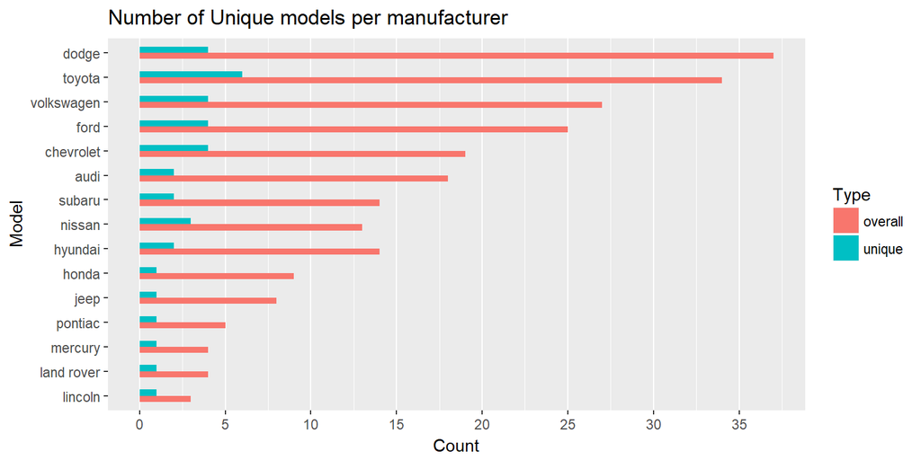

```r
require(stringr, quietly = TRUE)

unique_model <- mpg %>%
    select(manufacturer, model)

unique_model$model <- str_trim(str_replace_all(unique_model$model, c("quattro" = "", "4wd" = "",
                                     "2wd" = "", "awd" = "")))

q4_3 <- unique_model %>%
    group_by(manufacturer) %>%
    transmute("n" = length(unique(model))) %>%
    unique() %>%
    ungroup() %>%
    arrange(desc(n))

df <- data.frame(rbind(q4_1, q4_3), "Type" = as.factor(rep(c("overall", "unique"), each = 15)))

ggplot(df, aes(x = reorder(as.factor(manufacturer), n), y = n, fill = Type)) +
    geom_bar(width = 0.5, stat = "identity", position = "dodge") +
    theme(panel.grid.major.y = element_blank(),
        panel.grid.minor.y = element_blank()) +
        scale_y_continuous(breaks = seq(0, 40, by = 5)) +
        ggtitle("Number of Unique models per manufacturer") +
        labs(y = "Count", x = "Model") +
        coord_flip()
```

```r
# rm(list = ls())
```

### Exercises 2.3.1

> **Question 1**:

> How would you describe the relationship between cty and hwy? Do you have any concerns about drawing conclusions from that plot?

> **Answer**:

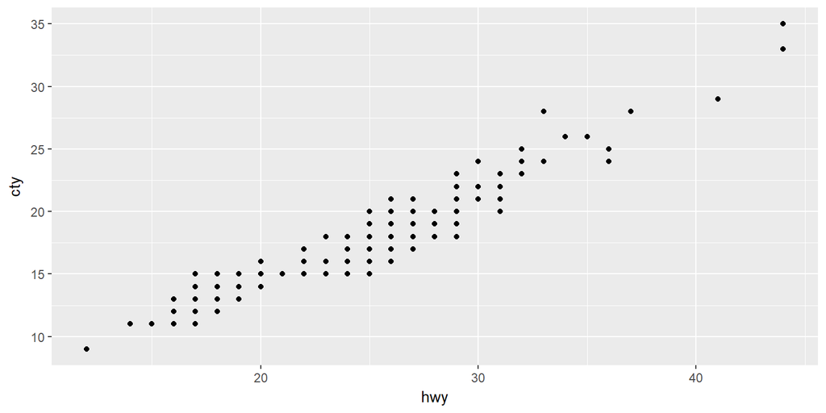

```r
ggplot(mpg, aes(hwy, cty)) +
    geom_point()
```

Strongly correlated. I would expect as much from intutition as they are both measurements of fuel economy.

> **Question 2**:

> What does ggplot( mpg, aes( model, manufacturer)) + geom_point() show? Is it useful? How could you modifiy the data to make it more informative?

> **Answer**:

```r
glimpse(mpg)
```

```
## Observations: 234
## Variables: 11
## $ manufacturer <chr> "audi", "audi", "audi", "audi", "audi", "audi", "...
## $ model        <chr> "a4", "a4", "a4", "a4", "a4", "a4", "a4", "a4 qua...
## $ displ        <dbl> 1.8, 1.8, 2.0, 2.0, 2.8, 2.8, 3.1, 1.8, 1.8, 2.0,...
## $ year         <int> 1999, 1999, 2008, 2008, 1999, 1999, 2008, 1999, 1...
## $ cyl          <int> 4, 4, 4, 4, 6, 6, 6, 4, 4, 4, 4, 6, 6, 6, 6, 6, 6...
## $ trans        <chr> "auto(l5)", "manual(m5)", "manual(m6)", "auto(av)...
## $ drv          <chr> "f", "f", "f", "f", "f", "f", "f", "4", "4", "4",...
## $ cty          <int> 18, 21, 20, 21, 16, 18, 18, 18, 16, 20, 19, 15, 1...
## $ hwy          <int> 29, 29, 31, 30, 26, 26, 27, 26, 25, 28, 27, 25, 2...
## $ fl           <chr> "p", "p", "p", "p", "p", "p", "p", "p", "p", "p",...
## $ class        <chr> "compact", "compact", "compact", "compact", "comp...
```

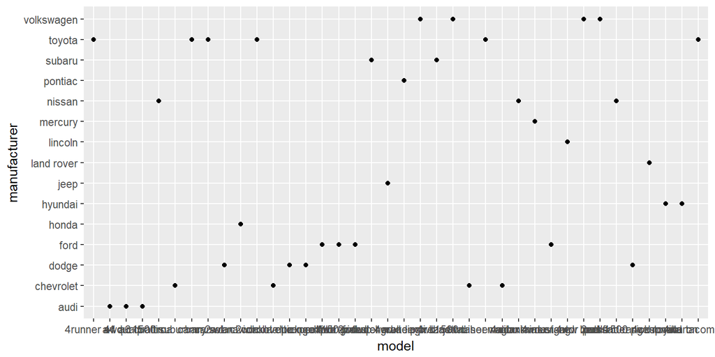

```r
ggplot(mpg, aes(model, manufacturer)) +
    geom_point()
```

```r
mpg %>% group_by(model, manufacturer)
```

| manufacturer | model | displ | year | cyl | trans | drv | cty | hwy | fl | class |
| --- | --- | --- | --- | --- | --- | --- | --- | --- | --- | --- |
| audi | a4 | 1.8 | 1999 | 4 | auto(l5) | f | 18 | 29 | p | compact |
| audi | a4 | 1.8 | 1999 | 4 | manual(m5) | f | 21 | 29 | p | compact |
| audi | a4 | 2.0 | 2008 | 4 | manual(m6) | f | 20 | 31 | p | compact |
| audi | a4 | 2.0 | 2008 | 4 | auto(av) | f | 21 | 30 | p | compact |
| audi | a4 | 2.8 | 1999 | 6 | auto(l5) | f | 16 | 26 | p | compact |
| audi | a4 | 2.8 | 1999 | 6 | manual(m5) | f | 18 | 26 | p | compact |
| audi | a4 | 3.1 | 2008 | 6 | auto(av) | f | 18 | 27 | p | compact |
| audi | a4 quattro | 1.8 | 1999 | 4 | manual(m5) | 4 | 18 | 26 | p | compact |
| audi | a4 quattro | 1.8 | 1999 | 4 | auto(l5) | 4 | 16 | 25 | p | compact |
| audi | a4 quattro | 2.0 | 2008 | 4 | manual(m6) | 4 | 20 | 28 | p | compact |

[output cut: 224 more lines]

It shows the manufacturer by model. It is not very useful. A better alternative might be:

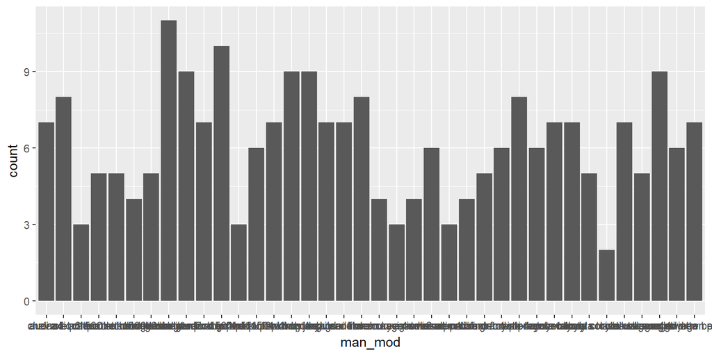

```r
df <- mpg %>%
    transmute("man_mod" = paste(manufacturer, model, sep = " "))

ggplot(df, aes(man_mod)) +
    geom_bar()
```

> **Question 3**:

Describe the data, aesthetic mappings and layers used for each of the following plots. You’ll need to guess a little because you haven’t seen all the data sets and functions yet, but use your common sense! See if you can predict what the plot will look like before running the code.

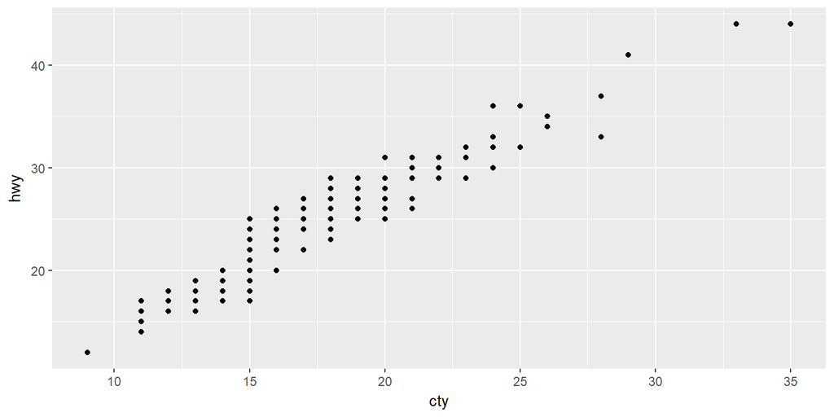

```r
ggplot(mpg, aes(cty, hwy)) + geom_point()
```

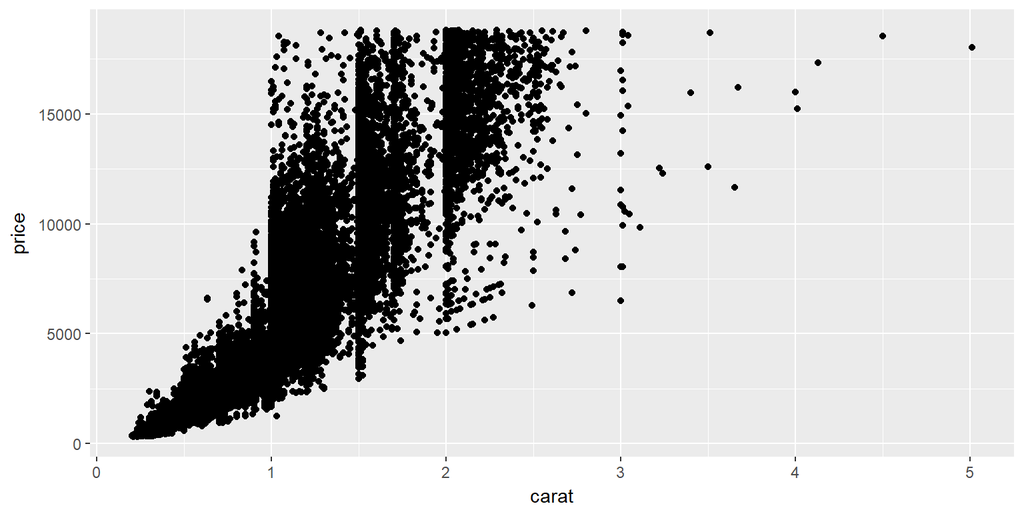

```r
ggplot(diamonds, aes(carat, price)) + geom_point()
```

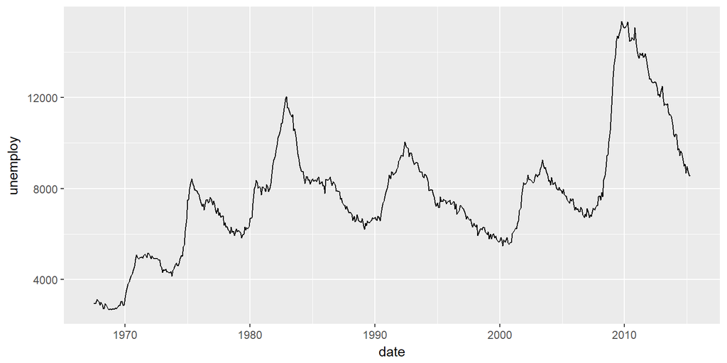

```r
ggplot(economics, aes(date, unemploy)) + geom_line()
```

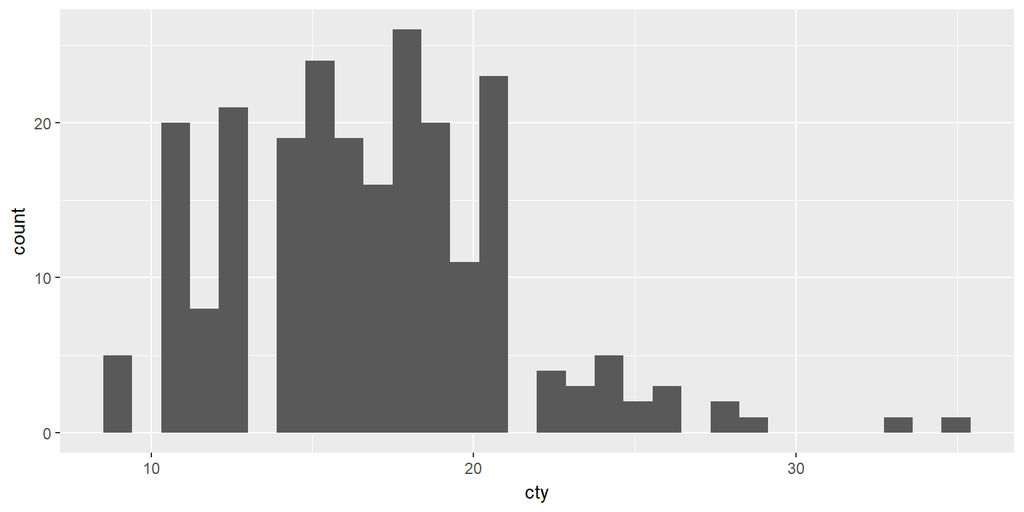

```r
ggplot(mpg, aes(cty)) + geom_histogram()
```

### Exercises 2.4.1

> **Question 1**:

> Experiment with the color, shape and size aesthetics. What happens when you map them to continuous values? What about categorical values? What happens when you use more than one aesthetic in a plot?

> **Answer**:

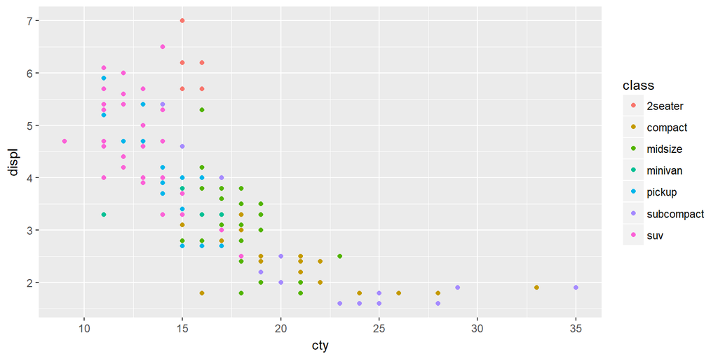

```r
# Categorial
ggplot(mpg, aes(cty, displ, colour = class)) +
    geom_point()
```

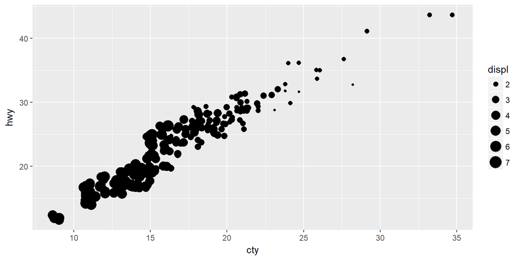

```r
# Continuous
ggplot(mpg, aes(cty, hwy, size = displ)) +
    geom_jitter()
```

> **Question 2**:

> What happens if you map a continuous variable to shape? Why? What happens if you map trans to shape? Why?

> **Answer**:

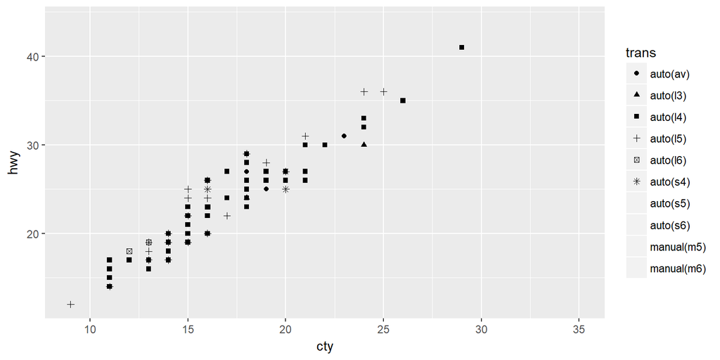

```r
ggplot(mpg, aes(cty, hwy, shape = trans)) +
    geom_point()
```

> **Question 2**:

> How is drive train related to fuel economy? How is drive train related to engine size and class?

> **Answer**:

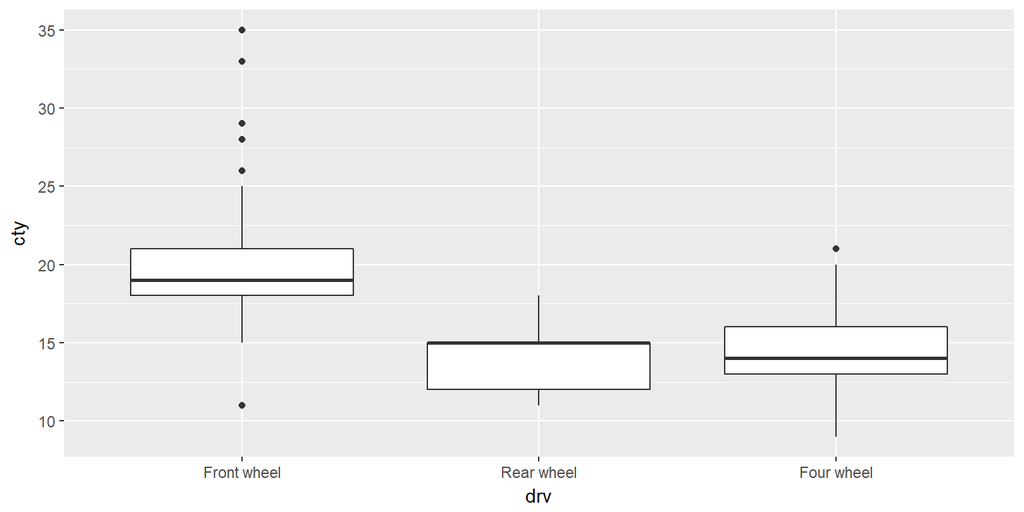

```r
ggplot(mpg, aes(drv, cty)) +
    geom_boxplot() +
    scale_x_discrete(limits = c("f", "r", "4"),
                   labels = c("Front wheel", "Rear wheel", "Four wheel"))
```

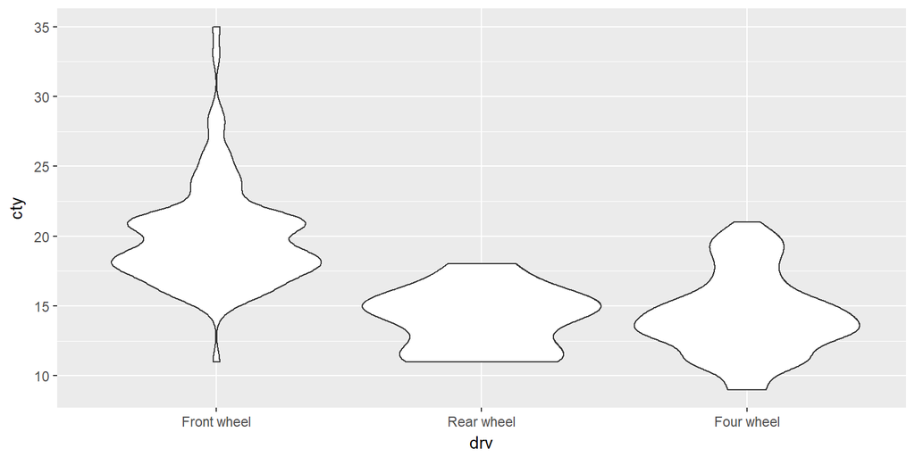

```r
ggplot(mpg, aes(drv, cty)) +
    geom_violin() +
    scale_x_discrete(limits = c("f", "r", "4"),
                   labels = c("Front wheel", "Rear wheel", "Four wheel"))
```

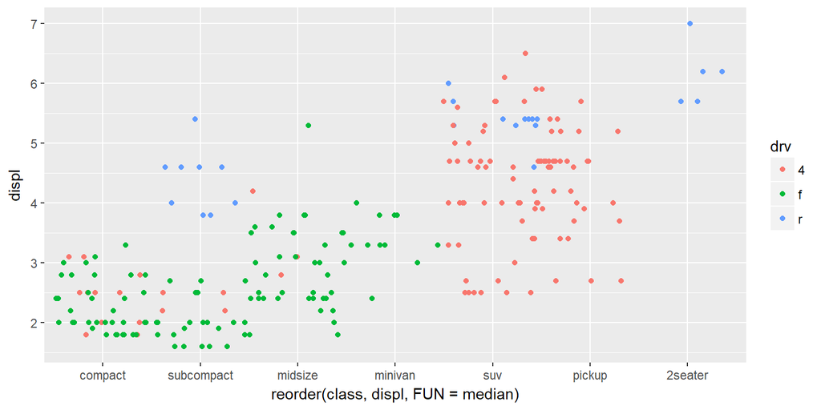

```r
ggplot(mpg, aes(reorder(class, displ, FUN = median), displ, colour = drv)) +
    geom_jitter(width = 0.5, height = 0)
```